# Task 2 - Parameter estimation

Alex Ehrens

3/3/2021

### 1) Read in and wrangle fish catch data

```r
# read in data, clean names, trim top/bottom extra rows, select only wild catch column, and convert columns to numeric
fish_catch <- read_csv(here("data", "fish_catch.csv"), skip = 2) %>%
  clean_names() %>%
  tail(-2) %>%
  head(-4) %>%
  select(year, wild_catch) %>%
  mutate(
    year = as.numeric(year),
    wild_catch = as.numeric(wild_catch)
  )

# mutate a new column assigning values starting from 0 with each year
n <- seq(0, 62)

fish_catch_n <- data.frame(fish_catch, n)
```

### 2) Create an (unfinished) exploratory plot of wild fish catch over time

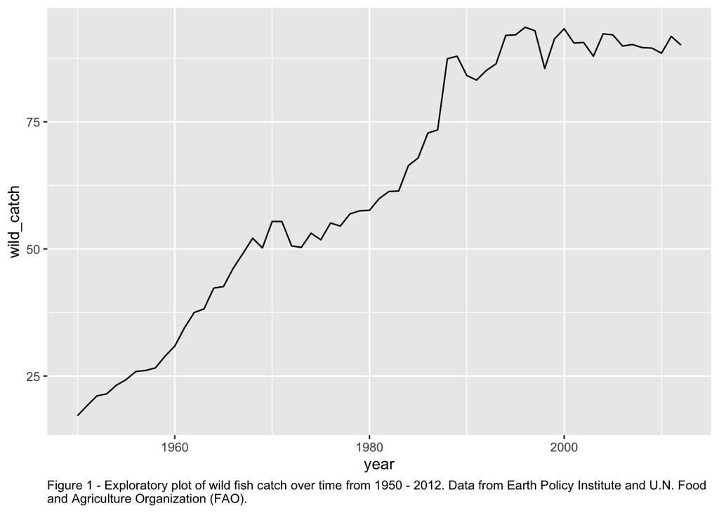

```r
# plot fish catch over time
ggplot(data = fish_catch_n) +
  geom_line(aes(x = year, y = wild_catch))+
  labs(caption = "Figure 1 - Exploratory plot of wild fish catch over time from 1950 - 2012. Data from Earth Policy Institute and U.N. Food \nand Agriculture Organization (FAO).") +
  theme(plot.caption = element_text(hjust = 0))
```

#### 2a) Model type:

The wild fish catch data in Figure 1 look like a logistic growth curve, where fish catch reaches a carrying capacity (K). The equation for that type of growth curve is as follows:

$P(t)=\frac{K}{1+Ae^{-kt}}$

where:

- $K$ is the carrying capacity
- $A$ is $\frac{K-P_0}{P_0}$
- $k$ is the growth rate constant

Values for k, A, and K will be estimated from the data and Figure 1. These estimates will be used as starting values for the nonlinear least squares parameter estimation. k is determined by calculating the linear slope of the exponential growth phase of the data (before curve starts leveling off at carrying capacity), K is estimated by looking at the fish catch value where the data plateaus in Figure 1, and A is calculated using the estimated carrying capacity and initial value of fish catch.

#### 2b) Find initial estimates for model parameters:

```r
# estimate k of exponential phase of growth (up to about 1988)
fish_catch_exp <- fish_catch_n %>%
  filter(year < 1988) %>%
  mutate(ln_wild_catch = log(wild_catch))

# Model linear to get *k* estimate (the slope of this linear equation is an estimate of the growth rate constant):
lm_k <- lm(ln_wild_catch ~ year, data = fish_catch_exp)
lm_k
```

```
##
## Call:
## lm(formula = ln_wild_catch ~ year, data = fish_catch_exp)
##
## Coefficients:
## (Intercept)         year
##   -66.00476      0.03543
```

```r
# Coefficient (k) ~ 0.035
```

Initial parameter estimates are as follows:

- k = 0.035
- K = 93
- A = 4.407

### 3) Use nonlinear least squares to find model parameters for wild catch rate

```r
# run nls() to find model paramteres
wild_catch_nls <- nls(wild_catch ~ K/(1 + A*exp(-k*n)),
                      data = fish_catch_n,
                      start = list(K = 93, A = 4.407, k = 0.035),
                      trace = TRUE
              )

summary(wild_catch_nls)
```

```r
# view results in tidy format
wild_catch_model <- broom::tidy(wild_catch_nls)

# put results in table
wild_catch_model %>%
  kable(digits = 2,
        caption = "Table 1. Estimates for each of the fish catch model parameters as determined by nonlinear least squares.",
        col.names = c("Parameter",
                      "Estimate",
                      "Std. Error",
                      "Statistic",
                      "p-value")) %>%
    kable_styling(bootstrap_options = "bordered",
                full_width = FALSE,
                position = "center")
```

Table 1. Estimates for each of the fish catch model parameters as determined by nonlinear least squares.

| Parameter | Estimate | Std. Error | Statistic | p-value |
| --- | --- | --- | --- | --- |
| K | 100.28 | 2.73 | 36.68 | 0 |
| A | 4.32 | 0.29 | 14.73 | 0 |
| k | 0.07 | 0.00 | 15.04 | 0 |

Therefore, the equation for wild fish catch model with the parameters estimated using a nonlinear least squares analysis is as follows:

$P(t)=\frac{100.28}{1+4.32e^{-0.07t}}$

### 4) Use NLS model parameters to predict wild fish catches

```r
# predict wild catch using model parameters from NLS
wild_catch_predict <- predict(wild_catch_nls)

# put that in data frame with original data
fish_catch_compare <- data.frame(fish_catch, wild_catch_predict)
```

### 5) Create plot comparing original data and NLS model output

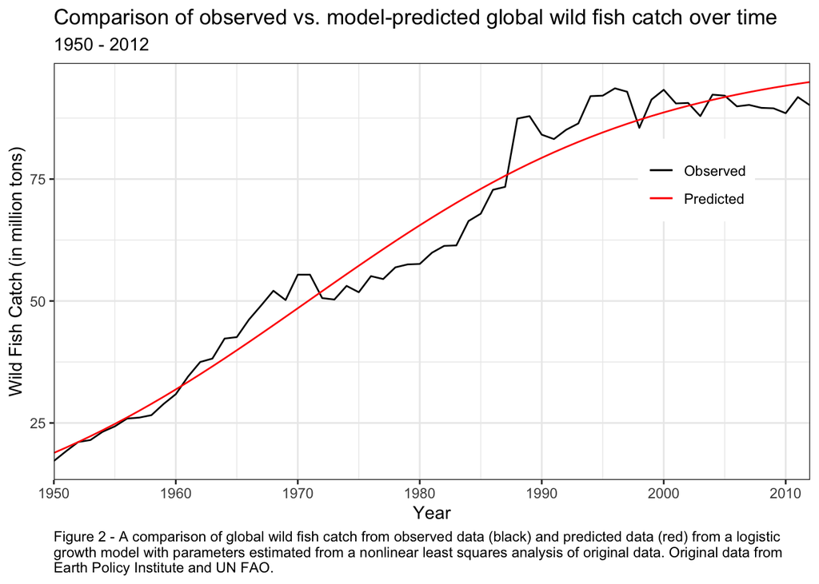

```r
ggplot(data = fish_catch_compare) +
  geom_line(aes(x = year, y = wild_catch, color = "Observed")) +
  geom_line(aes(x = year, y = wild_catch_predict, color = "Predicted")) +
  scale_color_manual(values = c("black", "red")) +
  scale_x_continuous(expand = c(0,0)) +
  theme_bw() +
  labs(title = "Comparison of observed vs. model-predicted global wild fish catch over time",
       subtitle = "1950 - 2012",
       x = "Year",
       y = "Wild Fish Catch (in million tons)",
       caption = "Figure 2 - A comparison of global wild fish catch from observed data (black) and predicted data (red) from a logistic \ngrowth model with parameters estimated from a nonlinear least squares analysis of original data. Original data from \nEarth Policy Institute and UN FAO.") +
  theme(plot.caption = element_text(hjust = 0),
        legend.title = element_blank(),
        legend.position = c(0.85, 0.72))
```

### Data Citation:

Global wild fish catch and aquaculture production, compiled by Earth Policy Institute with 1950-2010 from U.N. Food and Agriculture Organization (FAO), Global Capture Production and Global Aquaculture Production, electronic databases, at www.fao.org/fishery/topic/16140/en.

### END TASK 2